# Dati TL

## Importo i dati

Importo i dati e trasformo le variabili `Face` e `Income`.

```r
tl = read.csv("dataset/TL.csv") %>% tibble %>% dplyr::select(-X)
tl = tl %>% mutate_at(c( "MARSTAT"), as.factor)
colLog = c("FACE","INCOME")
tl = tl %>% mutate_at(colLog,log) %>% rename_at(colLog, function(c) paste("L",c,sep = ""))
tl
```

| AGE | MARSTAT | EDUCATION | NUMHH | LINCOME | LFACE |
| --- | --- | --- | --- | --- | --- |
| 30 | not single | 16 | 3 | 10.668955 | 9.903488 |
| 50 | not single | 9 | 3 | 9.392662 | 11.775290 |
| 39 | not single | 16 | 5 | 11.695247 | 14.220976 |
| 43 | not single | 17 | 4 | 10.596635 | 10.819778 |
| 34 | not single | 11 | 4 | 10.239960 | 12.301383 |
| 29 | not single | 16 | 3 | 11.512925 | 13.304685 |
| 72 | not single | 17 | 2 | 11.626254 | 11.512925 |
| 51 | not single | 16 | 4 | 9.615805 | 14.731801 |
| 58 | single | 14 | 1 | 10.373491 | 12.429216 |
| 73 | not single | 12 | 2 | 10.126631 | 10.819778 |

[output cut: 265 more lines]

```r
set.seed(1)
train = createDataPartition(tl$AGE,p = .7,list = F)
```

## Bagging

```r
set.seed(1)

modBagg = randomForest(LFACE ~ .,
                       data = tl,
                       subset = train,
                       mtry = length(tl) - 1,
                       importance = T)
modBagg
```

```
##
## Call:
##  randomForest(formula = LFACE ~ ., data = tl, mtry = length(tl) -      1, importance = T, subset = train)
##                Type of random forest: regression
##                      Number of trees: 500
## No. of variables tried at each split: 5
##
##           Mean of squared residuals: 2.311332
##                     % Var explained: 29.48
```

### Test

Nel grafico si possono osservare come sono distribuiti i residui secondo la variabile risposta del modello. Essi non sono distribuiti omogeneamente, il modello sovrastima i dati quando `LFACE` è minore, mentre li sottostima quando tendono a essere sopra la media.

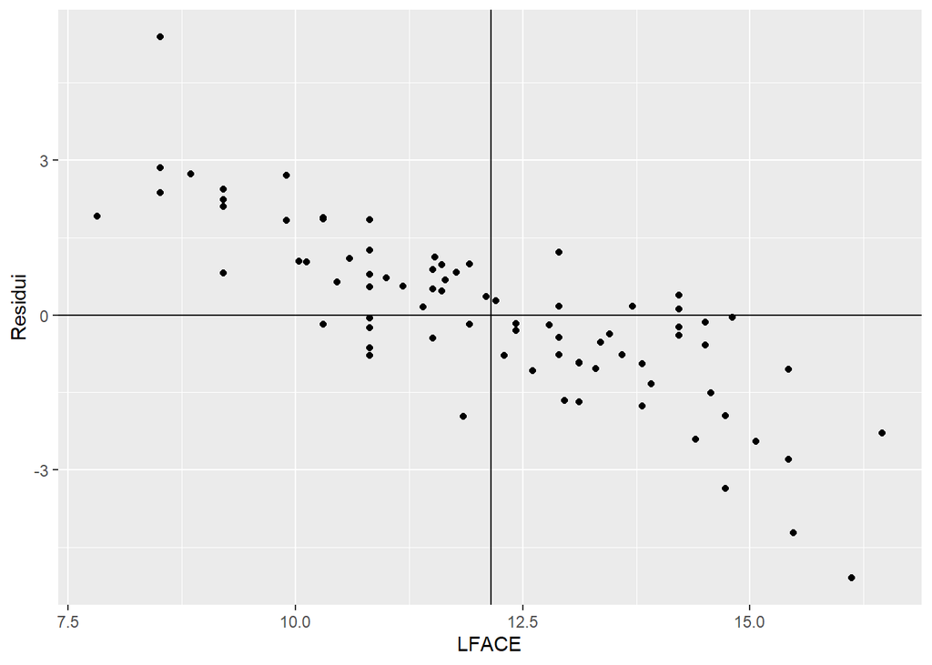

```r
yPred = predict(modBagg, newdata = tl[-train,])
ggplot(mapping = aes(x = tl$LFACE[-train], y = yPred-tl$LFACE[-train])) +
  geom_point() +
  geom_vline(aes(xintercept = mean(tl$LFACE[-train]))) +
  geom_hline(aes(yintercept = 0)) +
  xlab("LFACE") +
  ylab("Residui")
```

```r
mean((yPred-tl$LFACE[-train])**2)
```

```
## [1] 2.703698
```

## Random forest

```r
set.seed(1)

modRFor = randomForest(LFACE ~ .,
                       data = tl,
                       subset = train,
                       mtry = 3,
                       importance = T)

modRFor
```

```
##
## Call:
##  randomForest(formula = LFACE ~ ., data = tl, mtry = 3, importance = T,      subset = train)
##                Type of random forest: regression
##                      Number of trees: 500
## No. of variables tried at each split: 3
##
##           Mean of squared residuals: 2.247235
##                     % Var explained: 31.44
```

### Test

Anche in questo caso si ripresenta il problema precedente con i residui.

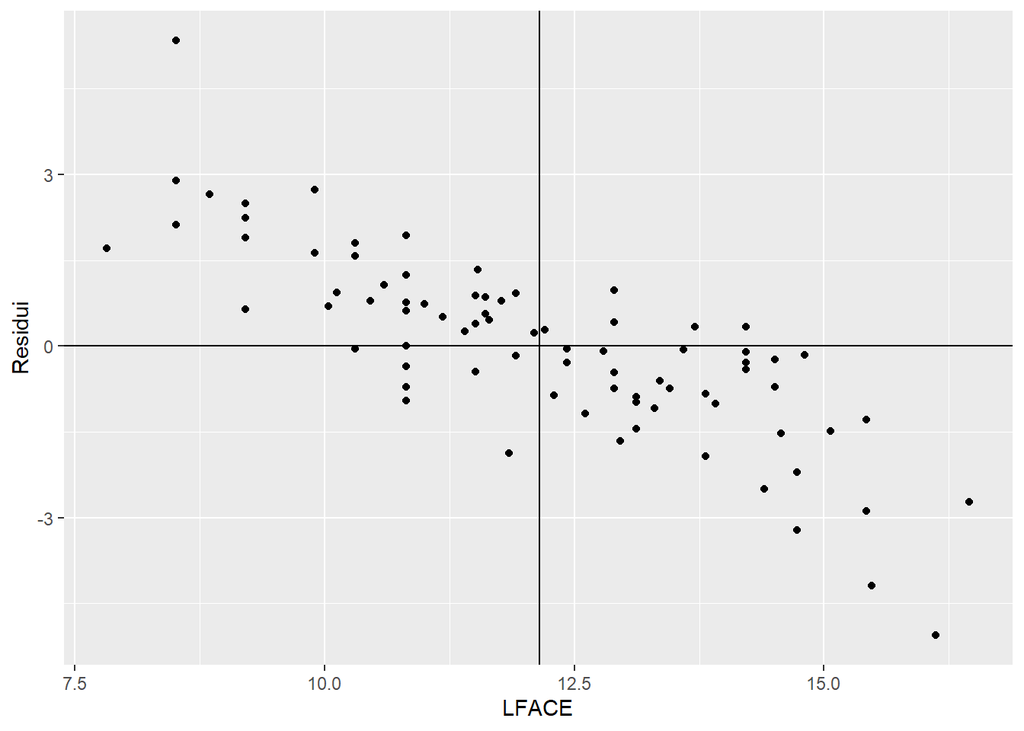

```r
yPred = predict(modRFor, newdata = tl[-train,])
ggplot(mapping = aes(x = tl$LFACE[-train], y = yPred-tl$LFACE[-train])) +
  geom_point() +
  geom_vline(aes(xintercept = mean(tl$LFACE[-train]))) +
  geom_hline(aes(yintercept = 0)) +
  xlab("LFACE") +
  ylab("Residui")
```

La media quadratica dei residui è pari a 2.61, leggermente minore a quella del bagging, ciò dimostra che il modello random forest migliore anche durante la *validation* con i dati di test.

```r
mean((yPred-tl$LFACE[-train])**2)
```

```
## [1] 2.618849
```

Nel seguente grafico sono riportate le variabili con la misura in percentuale di MSE che diminuisce quando viene inclusa quella variabile e con la misura della diminuzione totale dell’impurità del nodo.

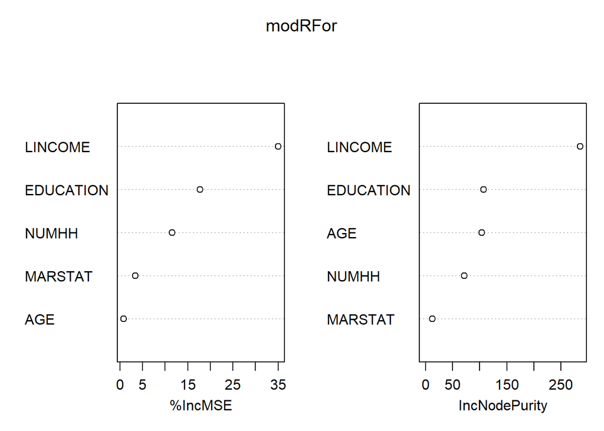

```r
varImpPlot(modRFor)
```

## Boosting

Per il boosting degli aberi sui dati è stato richiesto di produrre 1000 alberi con una profondità massima di 10.

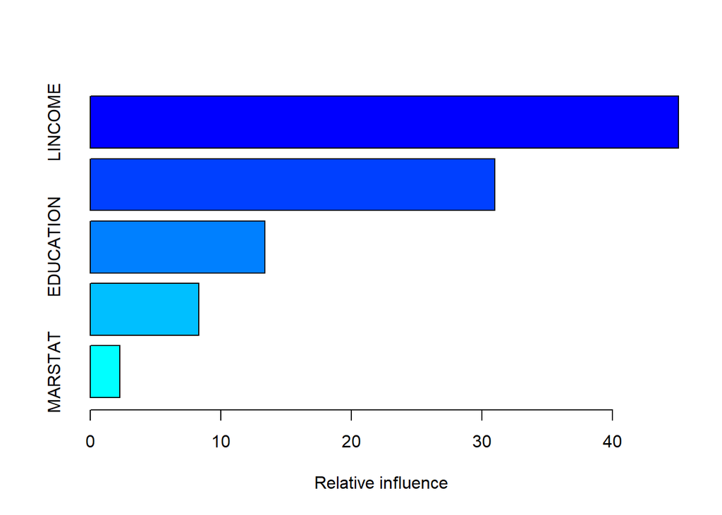

|  | var | rel.inf |
| --- | --- | --- |
| LINCOME | LINCOME | 45.061325 |
| AGE | AGE | 31.005482 |
| EDUCATION | EDUCATION | 13.370409 |
| NUMHH | NUMHH | 8.309278 |
| MARSTAT | MARSTAT | 2.253507 |

```r
modBoos = gbm(LFACE ~ .,
              data = tl,
              distribution = "gaussian",
              n.trees = 1000,
              interaction.depth = 10)

modBoos %>% summary
```

Nel seguente grafico è presente l’effetto marginale della variabile `LINCOME`.

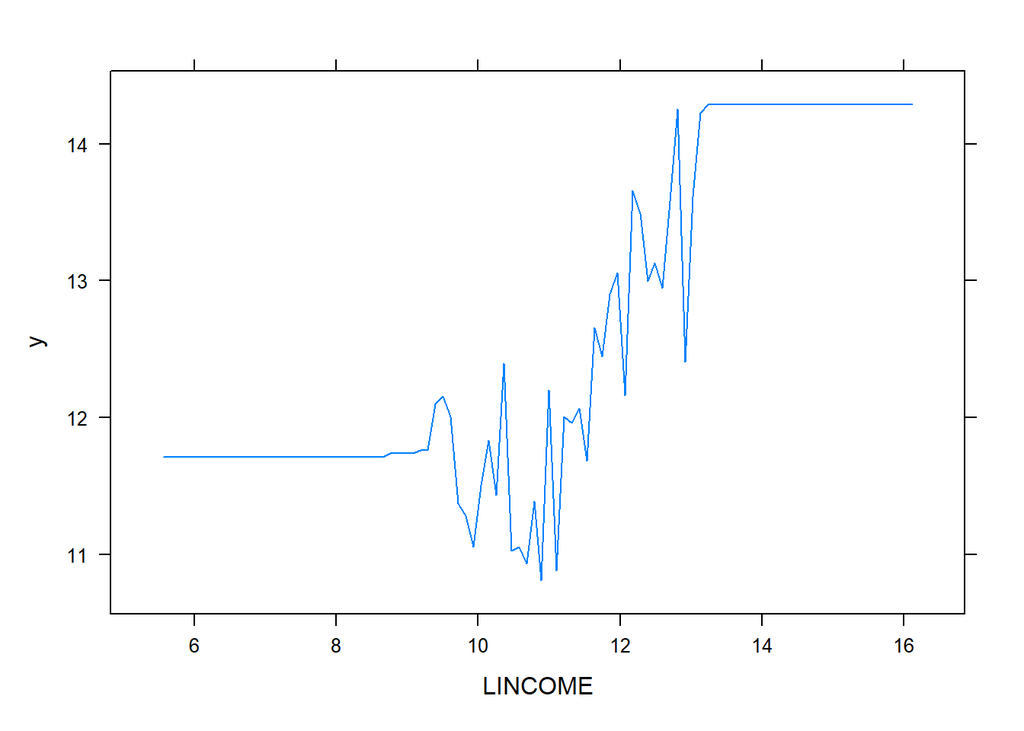

```r
plot(modBoos, i = "LINCOME")
```

### Test

Questo grafico è leggermente migliore confronto ai precedenti sulla distribuzione dei residui, inoltre se si osserva la grandezza di misura dell’asse delle ordinate si noterà quanto è diminuita confronto a prima.

```r
yPred = predict(modBoos, newdata = tl[-train,])
```

```
## Using 1000 trees...
```

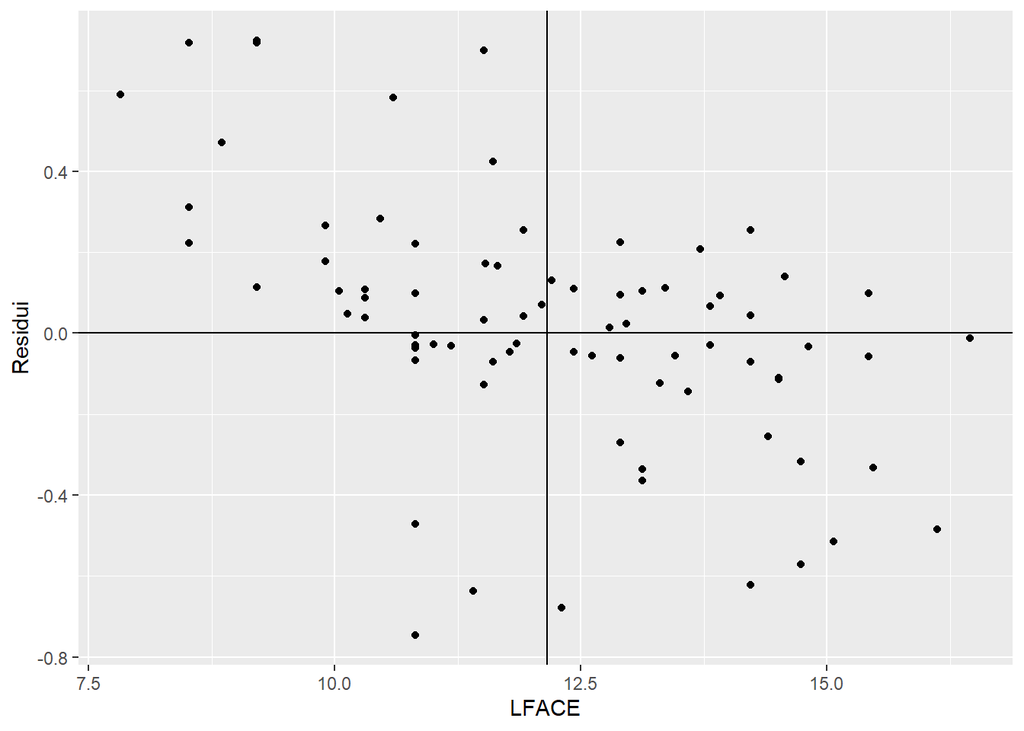

```r
ggplot(mapping = aes(x = tl$LFACE[-train], y = yPred-tl$LFACE[-train])) +
  geom_point() +
  geom_vline(aes(xintercept = mean(tl$LFACE[-train]))) +
  geom_hline(aes(yintercept = 0)) +
  xlab("LFACE") +
  ylab("Residui")
```

La media quadratica dei residui è pari a 0.10, all’incirca il 4% del MSE del modello random forest. Il boosting si rivela, in questo caso, il metodo migliore.

```r
mean((yPred-tl$LFACE[-train])**2)
```

```
## [1] 0.1005722
```

# Dati prostata

## Importo i dati

```r
pr = read.csv("dataset/prostate.csv") %>%
  as_tibble %>% dplyr::select(-X)
pr$svi = pr$svi %>% as.logical()
pr
```

| lcavol | lweight | age | lbph | svi | lcp | gleason | pgg45 | lpsa | train |
| --- | --- | --- | --- | --- | --- | --- | --- | --- | --- |
| -0.579818495 | 2.769459 | 50 | -1.38629436 | FALSE | -1.38629436 | 6 | 0 | -0.4307829 | TRUE |
| -0.994252273 | 3.319626 | 58 | -1.38629436 | FALSE | -1.38629436 | 6 | 0 | -0.1625189 | TRUE |
| -0.510825624 | 2.691243 | 74 | -1.38629436 | FALSE | -1.38629436 | 7 | 20 | -0.1625189 | TRUE |
| -1.203972804 | 3.282789 | 58 | -1.38629436 | FALSE | -1.38629436 | 6 | 0 | -0.1625189 | TRUE |
| 0.751416089 | 3.432373 | 62 | -1.38629436 | FALSE | -1.38629436 | 6 | 0 | 0.3715636 | TRUE |
| -1.049822124 | 3.228826 | 50 | -1.38629436 | FALSE | -1.38629436 | 6 | 0 | 0.7654678 | TRUE |
| 0.737164066 | 3.473518 | 64 | 0.61518564 | FALSE | -1.38629436 | 6 | 0 | 0.7654678 | FALSE |
| 0.693147181 | 3.539509 | 58 | 1.53686722 | FALSE | -1.38629436 | 6 | 0 | 0.8544153 | TRUE |
| -0.776528789 | 3.539509 | 47 | -1.38629436 | FALSE | -1.38629436 | 6 | 0 | 1.0473190 | FALSE |
| 0.223143551 | 3.244544 | 63 | -1.38629436 | FALSE | -1.38629436 | 6 | 0 | 1.0473190 | FALSE |

[output cut: 87 more lines]

```r
set.seed(1)
train = createDataPartition(pr$lcavol,p = .7,list = F)
```

## Bagging

```r
set.seed(1)

modBagg = randomForest(lpsa ~ .,
                       data = pr,
                       subset = train,
                       mtry = length(pr) - 1,
                       importance = T)
modBagg
```

```
##
## Call:
##  randomForest(formula = lpsa ~ ., data = pr, mtry = length(pr) -      1, importance = T, subset = train)
##                Type of random forest: regression
##                      Number of trees: 500
## No. of variables tried at each split: 9
##
##           Mean of squared residuals: 0.7474968
##                     % Var explained: 47.98
```

### Test

Nel grafico si possono osservare come sono distribuiti i residui secondo la variabile risposta del modello.

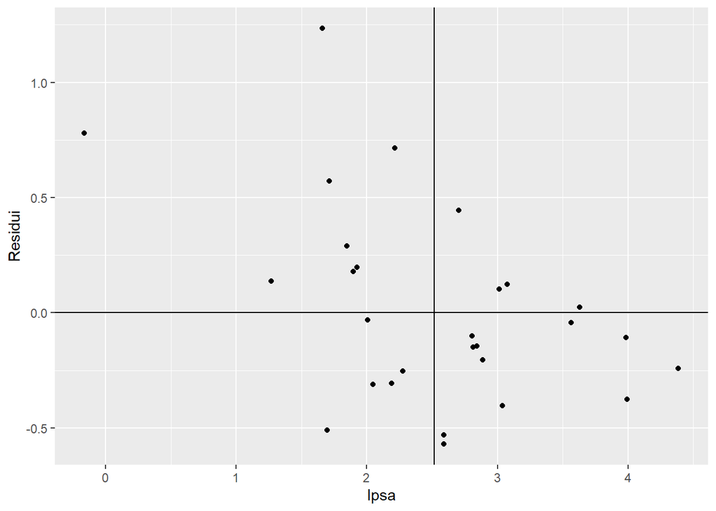

```r
yPred = predict(modBagg, newdata = pr[-train,])
ggplot(mapping = aes(x = pr$lpsa[-train], y = yPred-pr$lpsa[-train])) +
  geom_point() +
  geom_vline(aes(xintercept = mean(pr$lpsa[-train]))) +
  geom_hline(aes(yintercept = 0)) +
  xlab("lpsa") +
  ylab("Residui")
```

La media quadratica dei residui è pari a 0.177.

```r
mean((yPred-pr$lpsa[-train])**2)
```

```
## [1] 0.1770565
```

## Random forest

Le variabili da usare durante la creazione di una foresta casuale sono state impostate a 4, provando dove con 4 si ottiene un modello più performante che con le altre opzioni.

```r
set.seed(1)

modRFor = randomForest(lpsa ~ .,
                       data = pr,
                       subset = train,
                       mtry = 4,
                       importance = T)

modRFor
```

```
##
## Call:
##  randomForest(formula = lpsa ~ ., data = pr, mtry = 4, importance = T,      subset = train)
##                Type of random forest: regression
##                      Number of trees: 500
## No. of variables tried at each split: 4
##
##           Mean of squared residuals: 0.6910323
##                     % Var explained: 51.91
```

### Test

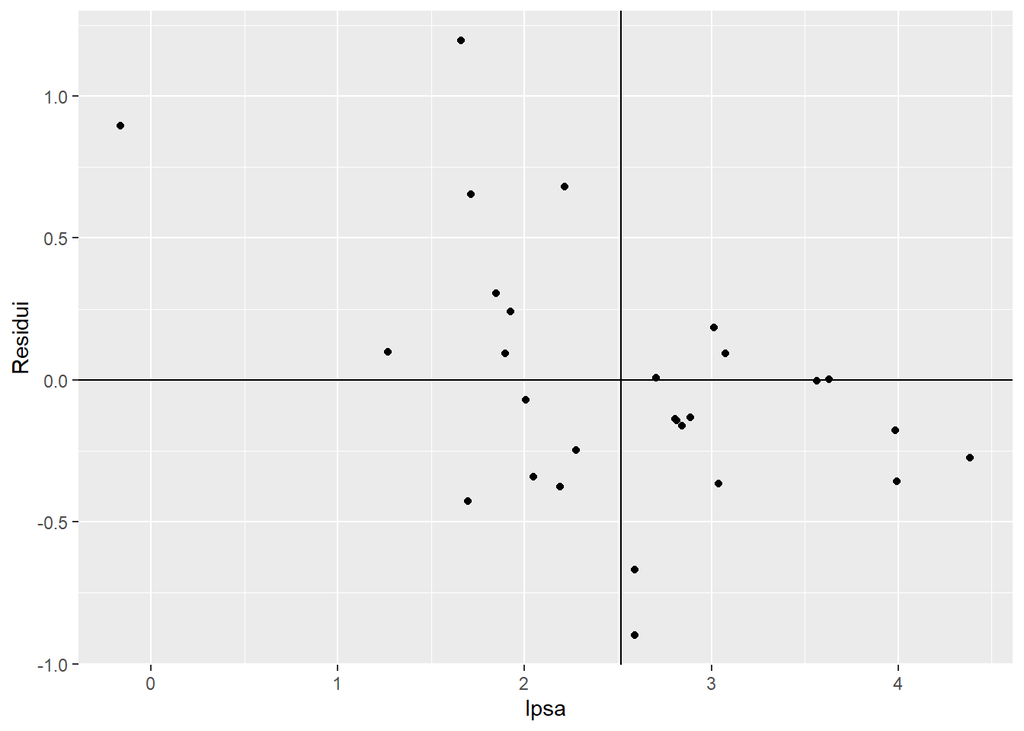

```r
yPred = predict(modRFor, newdata = pr[-train,])
ggplot(mapping = aes(x = pr$lpsa[-train], y = yPred-pr$lpsa[-train])) +
  geom_point() +
  geom_vline(aes(xintercept = mean(pr$lpsa[-train]))) +
  geom_hline(aes(yintercept = 0)) +
  xlab("lpsa") +
  ylab("Residui")
```

La media quadratica dei residui è pari a 0.198, più alta del 12% rispetto al bagging.

```r
mean((yPred-pr$lpsa[-train])**2)
```

```
## [1] 0.1981521
```

Nel seguente grafico sono riportate le variabili con la misura in percentuale di MSE che diminuisce quando viene inclusa quella variabile e con la misura della diminuzione totale dell’impurità del nodo.

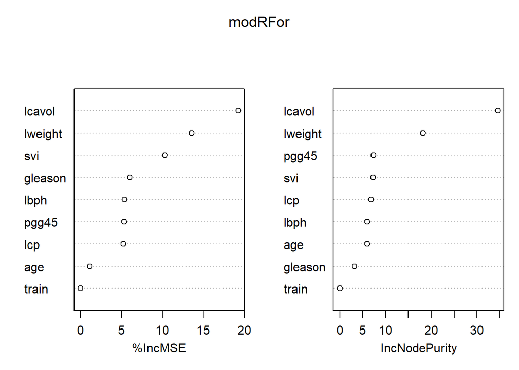

```r
varImpPlot(modRFor)
```

## Boosting

Per il boosting degli aberi sui dati è stato richiesto di produrre 1000 alberi con una profondità massima di 10.

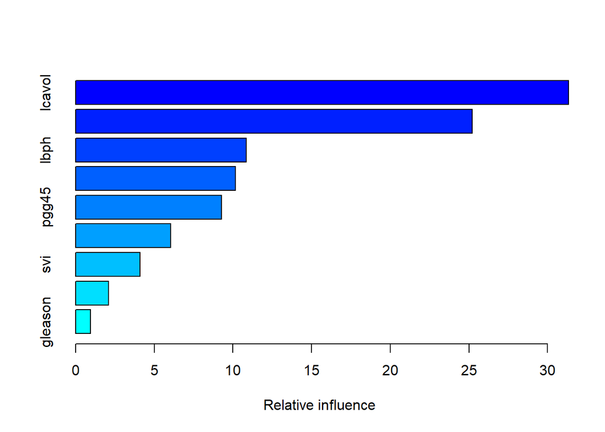

|  | var | rel.inf |
| --- | --- | --- |
| lcavol | lcavol | 31.3282941 |
| lweight | lweight | 25.2183785 |
| lbph | lbph | 10.8415659 |
| age | age | 10.1577510 |
| pgg45 | pgg45 | 9.2811150 |
| lcp | lcp | 6.0536853 |
| svi | svi | 4.0898583 |
| train | train | 2.0917804 |
| gleason | gleason | 0.9375715 |

```r
modBoos = gbm(lpsa ~ .,
              data = pr %>% mutate_if(is.logical, as.factor),
              distribution = "gaussian",
              n.trees = 1000,
              interaction.depth = 10)

modBoos %>% summary
```

Nel seguente grafico è presente l’effetto marginale della variabile `lcavol`.

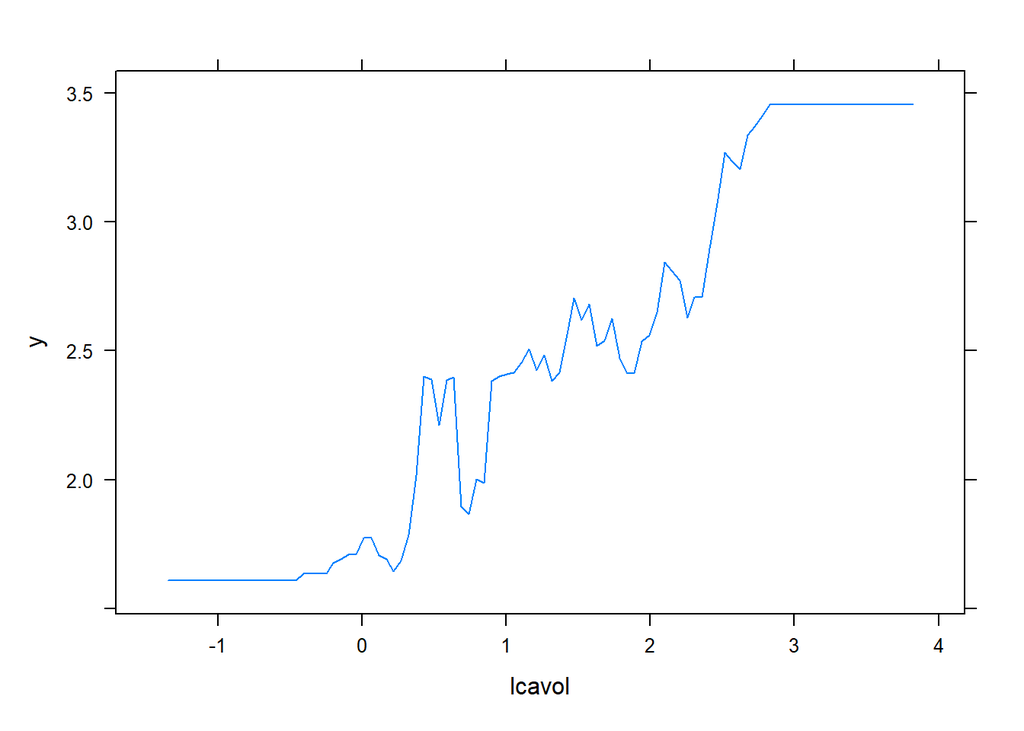

```r
plot(modBoos, i = "lcavol")
```

### Test

```r
yPred = predict(modBoos, newdata = pr[-train,])
```

```
## Using 1000 trees...
```

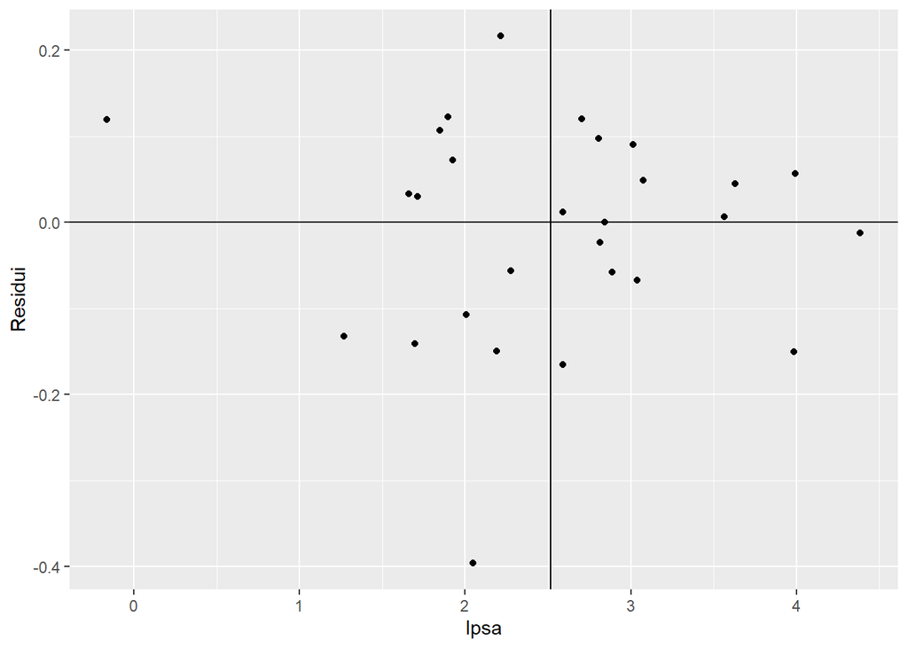

```r
ggplot(mapping = aes(x = pr$lpsa[-train], y = yPred-pr$lpsa[-train])) +
  geom_point() +
  geom_vline(aes(xintercept = mean(pr$lpsa[-train]))) +
  geom_hline(aes(yintercept = 0)) +
  xlab("lpsa") +
  ylab("Residui")
```

La media quadratica dei residui è pari a 0.015, all’incirca l’8% del MSE del modello bagging. Anche in questo caso il boosting si rivela il metodo migliore.

```r
mean((yPred-pr$lpsa[-train])**2)
```

```
## [1] 0.01518233
```

## Caret

Ripeto la creazione del modello random forest, questa volta tramite la libreria caret.

```r
set.seed(1)
modCaret = train(lpsa ~ .,
                 data = pr,
                 method = "rf",
                 importance = T,
                 trControl = trainControl("oob")
                 )
modCaret
```

```
## Random Forest
##
## 97 samples
##  9 predictor
##
## No pre-processing
## Resampling results across tuning parameters:
##
##   mtry  RMSE       Rsquared
##   2     0.7877793  0.5294018
##   5     0.7786405  0.5402569
##   9     0.8046302  0.5090539
##
## RMSE was used to select the optimal model using the smallest value.
## The final value used for the model was mtry = 5.
```

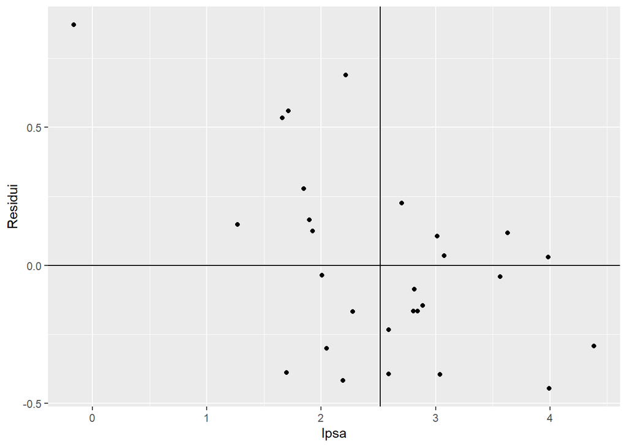

```r
yPred = predict(modCaret, newdata = pr[-train,])
ggplot(mapping = aes(x = pr$lpsa[-train], y = yPred-pr$lpsa[-train])) +
  geom_point() +
  geom_vline(aes(xintercept = mean(pr$lpsa[-train]))) +
  geom_hline(aes(yintercept = 0)) +
  xlab("lpsa") +
  ylab("Residui")
```

### Test

```r
mean((yPred-pr$lpsa[-train])**2)
```

```
## [1] 0.1155718
```

### Controllo dei parametri

Ora ripeto la procedura ma questa volta alcuni parametri li cambio: `mtry` corrisponde al numero di variabili casuali che il modello potrà scegliere a ogni nodo tra quelle disponibili, in `trainControlo` `number` sta per il numero di *fold* nella quale dovrà suddividere i dati e `repeats` è il numero di *fold* completi da ripetere.

```r
set.seed(1)
modCaretNew = train(lpsa~.,
                    data = pr,
                    method = 'rf',
                    metric = 'RMSE',
                    importance = T,
                    tuneGrid = expand.grid(.mtry = 7), #round(sqrt(ncol(pr)))),
                    trControl = trainControl(method = 'repeatedcv',
                                             number = 10,
                                             repeats = 3))
modCaretNew
```

```
## Random Forest
##
## 97 samples
##  9 predictor
##
## No pre-processing
## Resampling: Cross-Validated (10 fold, repeated 3 times)
## Summary of sample sizes: 86, 89, 88, 86, 88, 89, ...
## Resampling results:
##
##   RMSE       Rsquared   MAE
##   0.7493033  0.6266579  0.6121985
##
## Tuning parameter 'mtry' was held constant at a value of 7
```

```r
yPred = predict(modCaretNew, newdata = pr[-train,])
mean((yPred-pr$lpsa[-train])**2)
```

```
## [1] 0.09751975
```